# An extended look at crime (types) in Phoenix in 2020

14 February, 2024

In a prior post, I discuss general trends in [crime in Phoenix](https://jacobtnyoung.github.io/R2PhX/projects/PHXcrime_trends.html). In this post, I want to focus more attention on changes observed for 2020 and draw attention to the considerable decline in crime relative to other years. If you are interested in the most recent analysis of crime data, take a look at my [crime types in Phoenix](https://jacobtnyoung.github.io/R2PhX/projects/PHXcrime_types.html) page that is routinely updated.

Here, I want to further unpack the trends by focusing on crime types.

*Note: as with other posts, just click the tab to see the code*…

### Monthly Counts over the Years

Let’s pull the most recent data for **crime incidents** from the site.

The data are reported as UCR crime classifications and have geographic information (block address, zip) as well as the date and time of the incident. As of February, 2024, there were 526,426 crime incidents with complete data from 11/2015 to within a week of the current date. Since we are focusing on 2020, we will delete the data for 2021 and forward.

Let’s start by looking at the monthly count of incidents over all crime types.

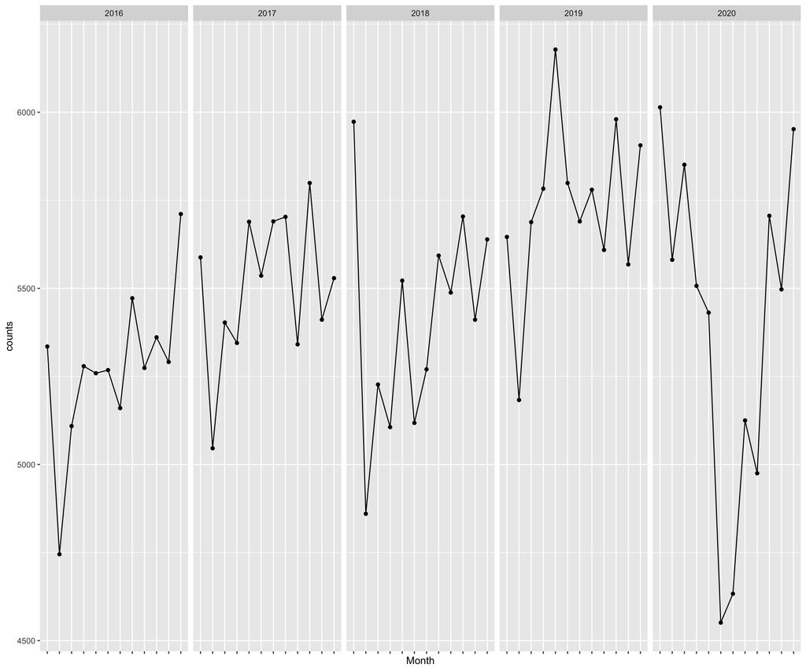

As the plot shows, there is a large drop in reported incidents from March 2020-June 2020 with an increase going into the end of 2020. The plot below shows these same counts broken down by type of incident reported.

If we focus on 2020, we can see that the pronounced drop in reported incidents from March 2020-June 2020 is mainly driven by **Robbery** and **Theft**.

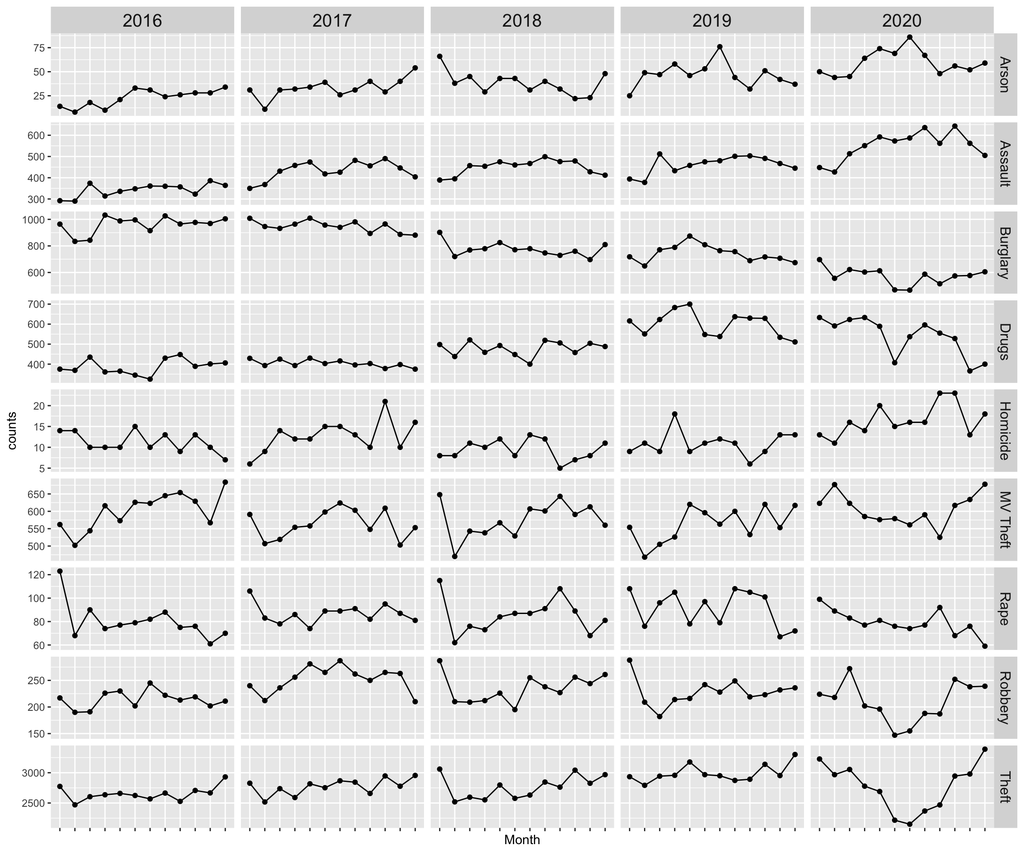